# Contract Termination

Greg Sanders

Wednesday, February 8, 2017

# Modeling Likelihood of Contract Termination

# Setup

```
##
## arm (Version 1.9-3, built: 2016-11-21)
```

```
## Working directory is C:/Users/gsand_000.ALPHONSE/Documents/Development/Vendor
```

Contracts are classified using a mix of numerical and categorical variables. While the changes in numerical variables are easy to grasp and summarize, a contract may have one line item that is competed and another that is not. As is detailed in the exploration on R&D, we are only considering information available prior to contract start. The percentage of contract obligations that were competed is a valuable benchmark, but is highly influenced by factors that occured after contract start..

## Contract Terminations

Contract terminations and the number of change orders can be calculated for the entire sample. Contract termination is determined using the *Reason for Modification* field in FPDS. A contract is considered to be terminated if it has at least one modification with the following values:

- “Terminate for Default (complete or partial)”
- “Terminate for Convenience (complete or partial)”
- “Terminate for Cause”
- “Legal Contract Cancellation”

These four catetegories and the “Close Out” category are used to mark a contract as closed. Many contracts in FPDS and in the sample are never marked closed.

## Prepare Data

First we load the data. The dataset used is a U.S. Defense Contracting dataset derived from FPDS.

### Data Transformations

After the data is loaded, we perform a series of transformations, creating derived variables that fit our purposes.

- l_Ceil is the natural log of the initial contract cost ceiling (UnmodifiedContractBaseAndAllOptionsValue).
- l_Days is the natural log of the initial maximum contract duration in days (UnmodifiedDays)
- Changing the unlabeled option for International to NA as it should not be seperately computed.
- b_Term transforms the factor that reports whether a contract was terminated (Term) to a numerical variable, 0 for no terminations, 1 for any partial or complete terminations.
- n_Fixed transforms the factor that reports whether a contract was fixed price or cost-based (FxCB) to a numberical value. 0 for cost-based, 0.5 or “combination or other”, 1 for any fixed price (excluding fixed-price level of effort which is classified as cost-based).
- nIncent transforms the factor that reports the fee type (Fee) to a numerical value. 1 for incentive fee or cost sharing, 0.5 or “combination or other”, 0 for all remaining types
- nComp transforms the factor that reports the fee type (cb_Comp) to a numerical value. 1 for Competed, 0 for not competed.
- n_UCA transforms the factor that reports the use of undefinitized contract awards (UCA) to a numerical value. 1 for UCA, 0 for otherwise.
- lOffer is the natural log of the number of offers received. Uncompeted contracts are classified as having received one offer.

In addition, l_Ceil and l_Days are rescaled to have an average value of 0 and a standard deviation of one. This standardizes interpretation and prevents a “very large eigen value” error later when l_Ceil:lDay is introduced.

```r
  load(file="Data/defense_contract_CSIScontractID_detail.Rdata")


head(DefenseModelAndDetail)
```

```
##   CSIScontractID                 FxCb                      Fee Comp
## 1        5261947          Fixed-Price            FFP or No Fee    1
## 2       63603967          Fixed-Price Combination or Other Fee    1
## 3       22544223 Combination or Other Combination or Other Fee    0
## 4        9334467          Fixed-Price            FFP or No Fee    1
## 5       61736309          Fixed-Price            FFP or No Fee    1
## 6       22071327          Fixed-Price            FFP or No Fee    0
##             Who                        What      Intl      PSR
## 1     Other DoD Facilities and Construction Just U.S. Products
## 2 Uncategorized                       Other Unlabeled Products
## 3     Other DoD         Aircraft and Drones Just U.S. Products
## 4          Army Facilities and Construction Just U.S. Services
## 5     Other DoD                       Other Just U.S. Products
## 6     Other DoD         Aircraft and Drones Just U.S. Products
##               LowCeil                Ceil             Dur SingleOffer
```

[output cut: 41 more lines]

Next, we eliminate missing data entries and then draw a sample. The final computation uses all of the data, but as a computation shortcut, only a subset of the data is needed to allow for processing of models in minutes rather than hours.

### Computational Sample Creation

```r
DefenseModelAndDetail<-transform_contract(DefenseModelAndDetail)
Term_smp<-DefenseModelAndDetail[!is.na(DefenseModelAndDetail$b_Term)&
                                  !is.na(DefenseModelAndDetail$Comp),]


Term_smp<-Term_smp[sample(nrow(Term_smp),250000),]


Term_smp$cl_Ceil<-scale(Term_smp$l_Ceil)
Term_smp$cl_Days<-scale(Term_smp$l_Days)
Term_smp$cb_Comp<-scale(Term_smp$b_Comp)
Term_smp$cn_Comp<-scale(Term_smp$n_Comp)
Term_smp$cn_Offr<-scale(Term_smp$n_Offr)
Term_smp$cl_Offer<-scale(Term_smp$l_Offer)


head(Term_smp)
```

```
##          CSIScontractID        FxCb                      Fee Comp
## 217902         63748753 Fixed-Price Combination or Other Fee    1
## 8684335        60711081 Fixed-Price Combination or Other Fee    0
## 11100305       63994008 Fixed-Price Combination or Other Fee    1
## 6168115        24702086 Fixed-Price            FFP or No Fee    0
## 2588907        65595020 Fixed-Price            FFP or No Fee    0
## 1902140        65340974 Fixed-Price Combination or Other Fee    1
##                    Who                           What      Intl      PSR
## 217902   Uncategorized                          Other Unlabeled Products
## 8684335      Other DoD    Facilities and Construction Just U.S. Products
## 11100305 Uncategorized                          Other Unlabeled Products
## 6168115           Army    Facilities and Construction Just U.S. Services
## 2588907  Uncategorized Electronics and Communications Unlabeled Services
## 1902140  Uncategorized                          Other Unlabeled Products
##                      LowCeil                Ceil             Dur
```

[output cut: 69 more lines]

# Estimate Model

## Study Variable: Competition

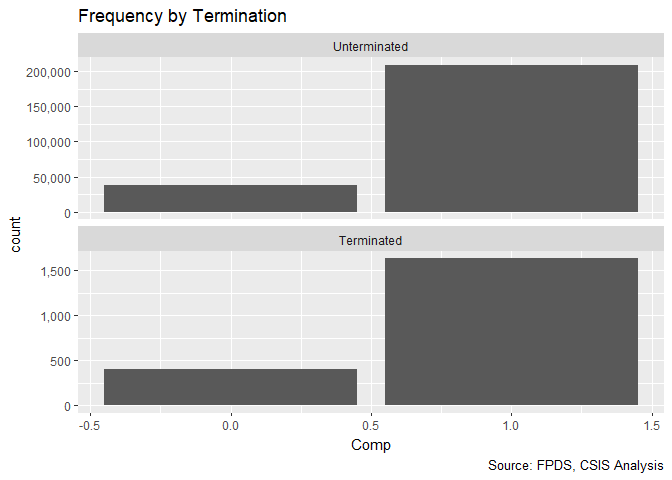

```r
#Frequency Plot
freq_discrete_term_plot(Term_smp,"Comp")
```

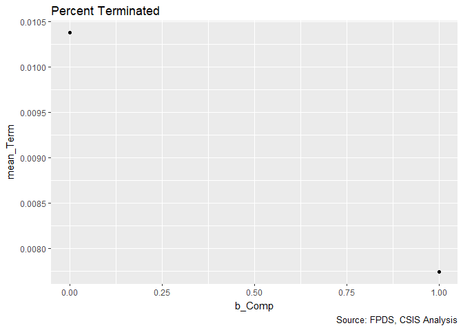

```r
#Percent Terminated Plot
discrete_percent_term_plot(Term_smp,"b_Comp")
```

```r
#Model
Term_01A <- glm (data=Term_smp,
                 b_Term ~ cb_Comp, family=binomial(link="logit"))
display(Term_01A)
```

```
## glm(formula = b_Term ~ cb_Comp, family = binomial(link = "logit"),
##     data = Term_smp)
##             coef.est coef.se
## (Intercept) -4.81     0.02
## cb_Comp     -0.11     0.02
## ---
##   n = 250000, k = 2
##   residual deviance = 23636.4, null deviance = 23662.8 (difference = 26.4)
```

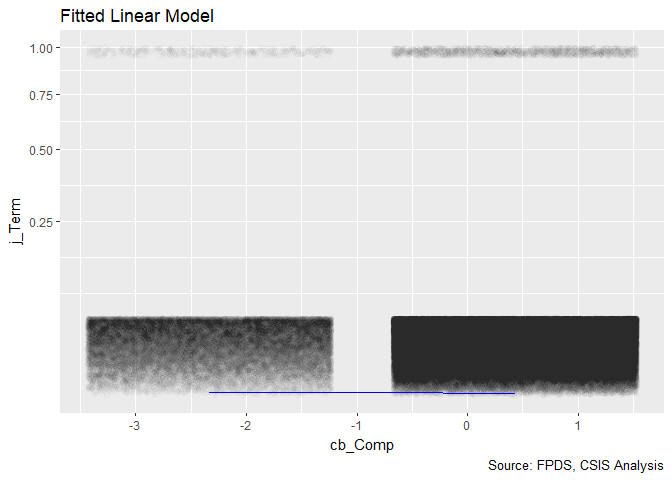

```r
#Plot the new variable and coefficients
#Add the fitted regression line
discrete_fitted_term_model(Term_smp,"cb_Comp") +
  stat_function(fun = fit_curve, args=list(a=coef(Term_01A)[1],                                                        b=coef(Term_01A)[2]),color="blue")
```

```r
#Save this for a future GLM
# Term_data_01A<-data.frame(fitted=fitted(Term_01A),
#                        residuals=residuals(Term_01A),
#                        nTerm=Term_01A@frame$nTerm,
#                        cb_Comp=Term_01A@frame$cb_Comp
#                        )
```

Competition alone has a very slight, but significant, negative correlation with terminations. The next step is to check alternate formulations. There’s not yet enough in this model for any meaningful residual models. The next step is to look at a more detailed model, where single offer competition is broken out as a middle option between competition and no competion.

### Model 01B: No Competition / Single Offer / Competition

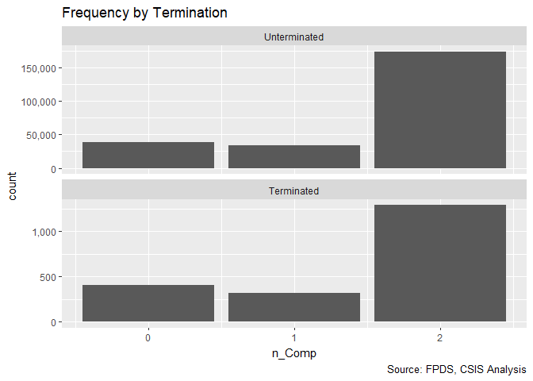

```r
#Frequency Plot
freq_discrete_term_plot(Term_smp,"n_Comp")
```

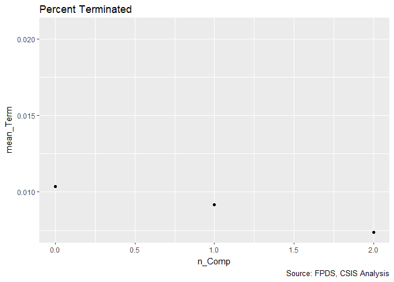

```r
#Percent Terminated Plot
discrete_percent_term_plot(Term_smp,"n_Comp")
```

```r
#Model
Term_01B <- glm (data=Term_smp,
                 b_Term ~ cn_Comp, family=binomial(link="logit"))
display(Term_01B)
```

```
## glm(formula = b_Term ~ cn_Comp, family = binomial(link = "logit"),
##     data = Term_smp)
##             coef.est coef.se
## (Intercept) -4.82     0.02
## cn_Comp     -0.13     0.02
## ---
##   n = 248649, k = 2
##   residual deviance = 23331.9, null deviance = 23371.7 (difference = 39.8)
```

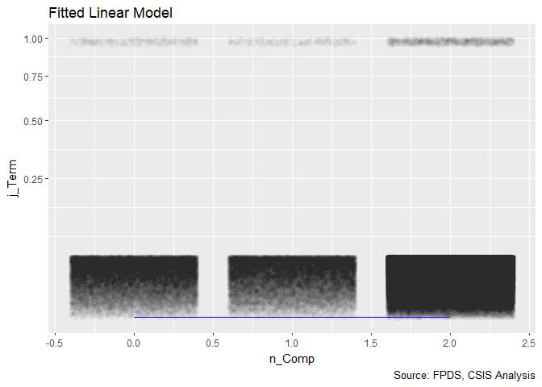

```r
#Plot the Fitted
#Add the fitted regression line
discrete_fitted_term_model(Term_smp,"n_Comp") +
  stat_function(fun = fit_curve, args=list(a=coef(Term_01B)[1],
                                           b=coef(Term_01B)[2]),
                color="blue")
```

### Model 01C: No Competition / Number of Offer Categories

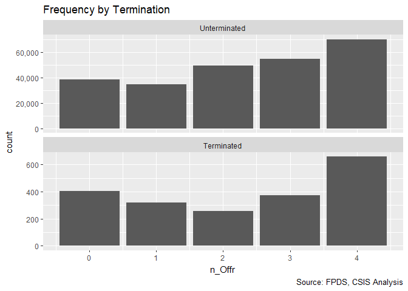

```r
#Frequency Plot
freq_discrete_term_plot(Term_smp,"n_Offr")
```

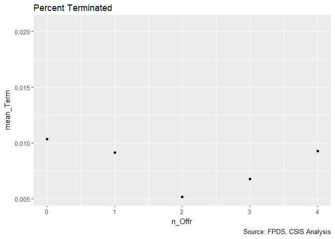

```r
#Percent Terminated Plot
discrete_percent_term_plot(Term_smp,"n_Offr")
```

```r
#Model
Term_01C <- glm (data=Term_smp,
                 b_Term ~ cn_Offr, family=binomial(link="logit"))
display(Term_01C)
```

```
## glm(formula = b_Term ~ cn_Offr, family = binomial(link = "logit"),
##     data = Term_smp)
##             coef.est coef.se
## (Intercept) -4.81     0.02
## cn_Offr     -0.04     0.02
## ---
##   n = 248649, k = 2
##   residual deviance = 23368.5, null deviance = 23371.7 (difference = 3.2)
```

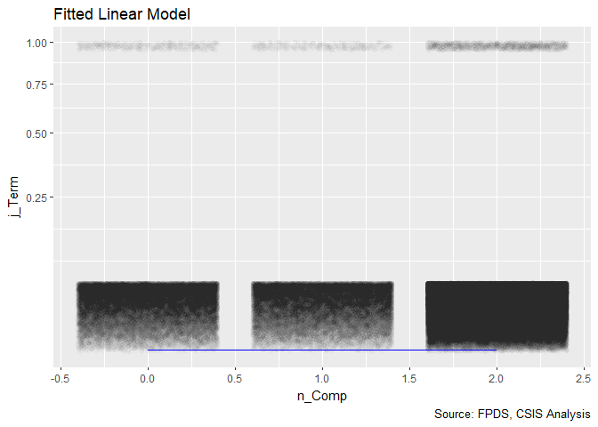

```r
#Plot the Fitted
#Add the fitted regression line
discrete_fitted_term_model(Term_smp,"n_Comp") +
  stat_function(fun = fit_curve, args=list(a=coef(Term_01C)[1],
                                           b=coef(Term_01C)[2]),
                color="blue")
```

Instead, the last variant to be checked is the number of offers directly. This is handled logarithmicly because the differences between number of offers at the bottom end of the scale mtters much more than at the high end of the scale. In this method, contracts that were not open to competition are grouped with contracts that received only a single offer.

### Model 01D: Number of Offer Categories

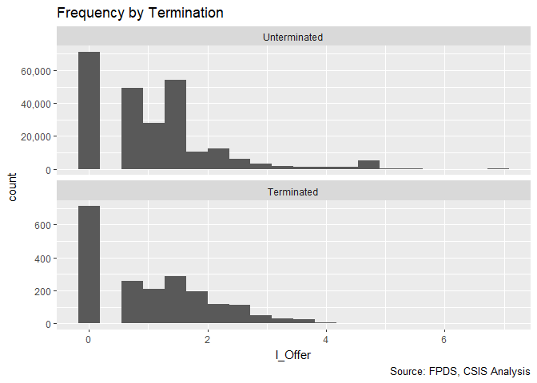

```r
#Frequency Plot
freq_continuous_term_plot(Term_smp,"l_Offer")
```

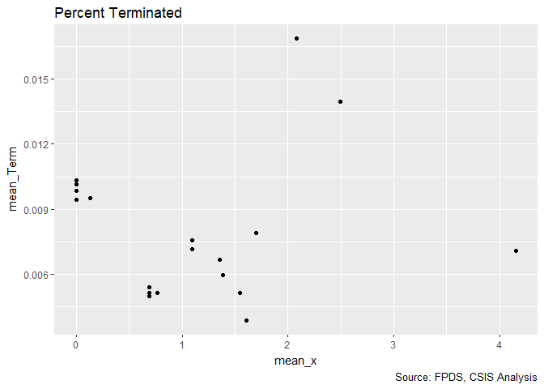

```r
#Percent Terminated Plot
binned_percent_term_plot(Term_smp,"l_Offer")
```

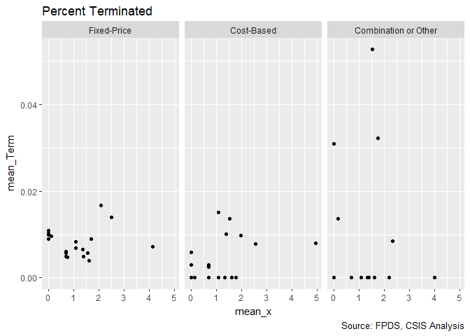

```r
#Percent Terminated Plot
binned_percent_term_plot(Term_smp,"l_Offer","FxCb")
```

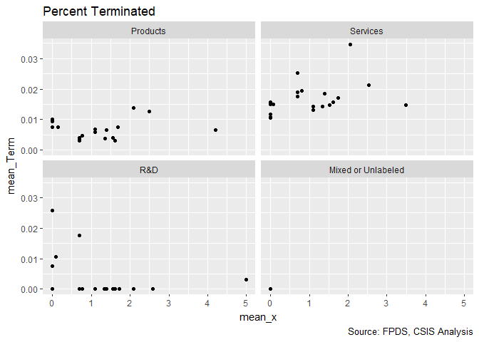

```r
#Percent Terminated Plot
binned_percent_term_plot(Term_smp,"l_Offer","PSR")
```

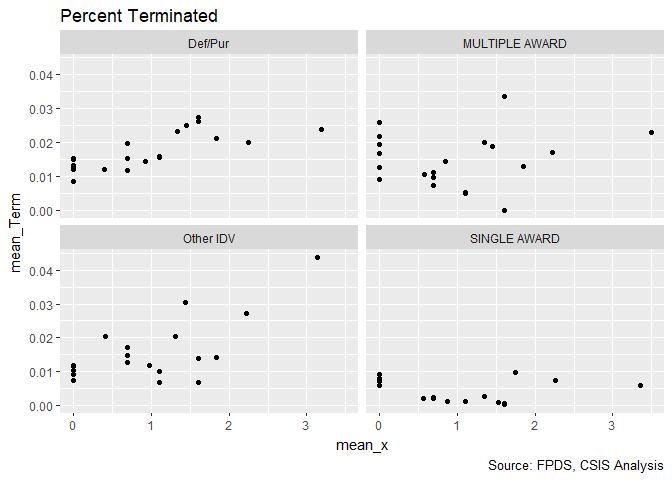

```r
#Percent Terminated Plot
binned_percent_term_plot(Term_smp,"l_Offer","Veh")
```

```r
#Model
Term_01D <- glm (data=Term_smp,
                 b_Term ~ cl_Offer, family=binomial(link="logit"))
display(Term_01D)
```

```
## glm(formula = b_Term ~ cl_Offer, family = binomial(link = "logit"),
##     data = Term_smp)
##             coef.est coef.se
## (Intercept) -4.81     0.02
## cl_Offer    -0.02     0.02
## ---
##   n = 247962, k = 2
##   residual deviance = 23311.9, null deviance = 23312.4 (difference = 0.5)
```

```r
#Variant Model
Term_smp$clsqr_Offer<-Term_smp$cl_Offer^2
Term_01E <- glm (data=Term_smp,
                 b_Term ~ cl_Offer +clsqr_Offer, family=binomial(link="logit"))
display(Term_01E)
```

```
## glm(formula = b_Term ~ cl_Offer + clsqr_Offer, family = binomial(link = "logit"),
##     data = Term_smp)
##             coef.est coef.se
## (Intercept) -4.79     0.03
## cl_Offer     0.01     0.03
## clsqr_Offer -0.02     0.01
## ---
##   n = 247962, k = 3
##   residual deviance = 23310.4, null deviance = 23312.4 (difference = 2.1)
```

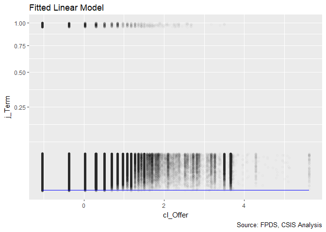

```r
#Plot the data and fitted curve
Term_01D_plot<-ggplot(data=Term_smp,
       aes(y=j_Term,x=cl_Offer))+geom_jitter(alpha=0.01,height=0)+scale_y_sqrt() +
  labs(title="Fitted Linear Model", caption="Source: FPDS, CSIS Analysis")

#Plot the Fitted
#Add the fitted regression line
discrete_fitted_term_model(Term_smp,"cl_Offer") +
  stat_function(fun = fit_curve, args=list(a=coef(Term_01D)[1],
                                           b=coef(Term_01D)[2]),
                             color="blue")
```

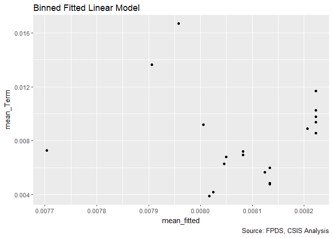

```r
#Plot the fitted data versus actual outcomes
Term_01D_data<-data.frame(fitted=fitted(Term_01D),
                       residuals=residuals(Term_01D),
                       b_Term=Term_01D$model$b_Term,
                       cl_Offer=Term_01D$model$cl_Offer
                       )


#Plot the fitted values vs actual results
Term_01D_data$bin_fitted<-bin_df(Term_01D_data,rank_col="fitted")
ggplot(data=subset(Term_01D_data,!is.na(fitted) & !is.na(b_Term) ) %>%
  group_by(bin_fitted) %>%
  summarise (mean_Term = mean(b_Term),
             mean_fitted =mean(fitted)),
       aes(y=mean_Term,x=mean_fitted))+geom_point()+
  labs(title="Binned Fitted Linear Model",
          caption="Source: FPDS, CSIS Analysis")
```

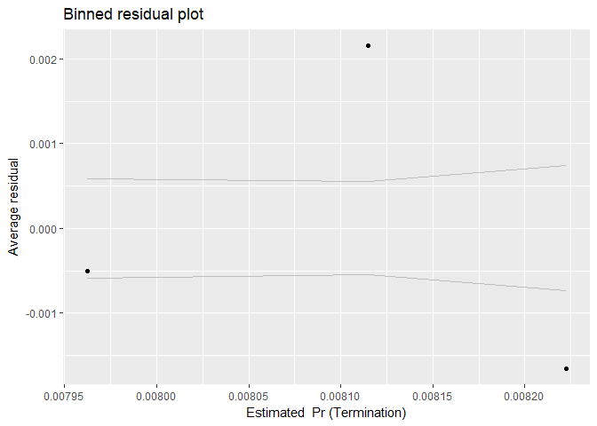

```r
#Plot the Residualts
Term_01D_res<-binned.resids (Term_01D_data$fitted,
                              Term_01D_data$fitted-Term_01D_data$b_Term, nclass=3)$binned

ggplot(data=Term_01D_res,
       aes(x=xbar,y-ybar))+
  geom_point(aes(y=ybar))+ #Residuals
  geom_line(aes(y=se2),col="grey")+
  geom_line(aes(y=-se2),col="grey")+
  labs(title="Binned residual plot",
       x="Estimated  Pr (Termination)",
       y="Average residual")
```

Closer examination further undercuts the idea that more offers is associated with a lower termination risk. As measured by deviance, the number offers adds less to the model than random noise. A quick experiment also found that use of number of offer squared only made the model slightly better than noise.

A variety of binned percent terminated graphs found that in the middle range of the number of offers, there is often an increase in the percent terminated. The study team had expected that this phenomenon may prove isolated to a certain type of contracting mechanism or product/service, but that did not prove to be the case.

The difference between single-offer and effective competition is worth exploring, even if it lowers the significance of the starting model. Happily, this decision is supported by the fact that this three category variable offers the greatest reduction in residual deviance. However, lacking a specific theoretical argument for the importance of a greater number of offers, and given the results, the more detailed competition breakdowns will not be used. This may be an issue worth exploring more in a future work.

The greatest distinctiveness can be found in types of indefinite delivery vehicles. Definitive contracts and purchase orders show a higher termination rate as the number of offers increase. However, for single and multiple award IDVs, there’s a decline in terminations rates correlated with low levels of competition, that often fades and even reverses as the number of offers increases. However, the results do not seem consistent with am exponential relationship.

## Scope Variables

### Model 02A: Cost Ceiling

The model starts by examing the influence of large ceilings on contracts, the core idea here, as observed in the fixed priced paper, is that larger contracts are at greater risk of termination. This can be explained by both the inherent risk in the contract and high transaction costs of contract termination which discourage making the effort for smaller contracts.

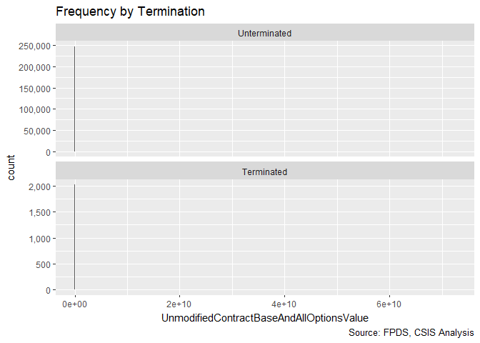

```r
#Frequency Plot for unlogged ceiling
freq_continuous_term_plot(Term_smp,"UnmodifiedContractBaseAndAllOptionsValue",
               bins=1000)
```

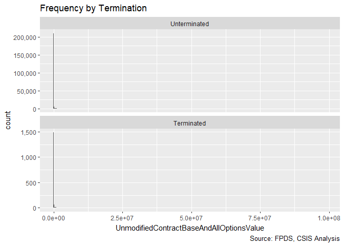

```r
freq_continuous_term_plot(subset(Term_smp,UnmodifiedContractBaseAndAllOptionsValue<100000000),
               "UnmodifiedContractBaseAndAllOptionsValue",
               bins=1000)
```

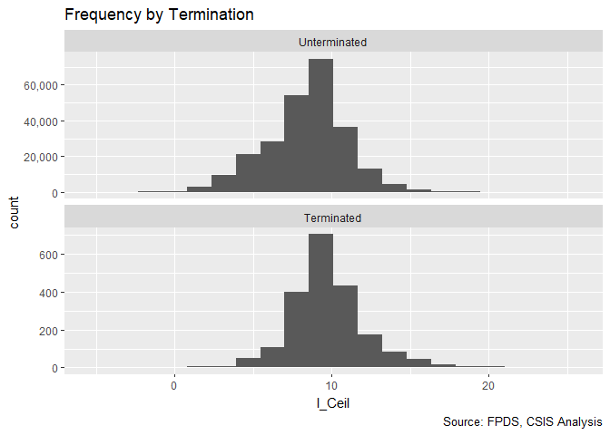

```r
#Frequency Plot for logged ceiling
freq_continuous_term_plot(Term_smp,"l_Ceil")
```

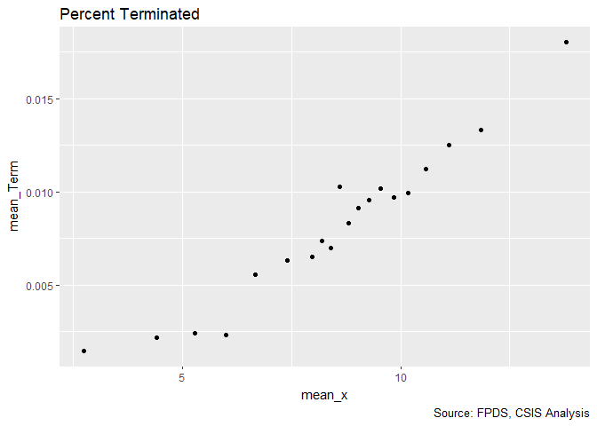

```r
#Percent Terminated Plot
binned_percent_term_plot(Term_smp,"l_Ceil")
```

```r
#Model
Term_02A <- glm (data=Term_smp,
                 b_Term ~n_Comp + cl_Ceil, family=binomial(link="logit"))
display(Term_02A)
```

```
## glm(formula = b_Term ~ n_Comp + cl_Ceil, family = binomial(link = "logit"),
##     data = Term_smp)
##             coef.est coef.se
## (Intercept) -4.80     0.05
## n_Comp      -0.09     0.03
## cl_Ceil      0.51     0.02
## ---
##   n = 248258, k = 3
##   residual deviance = 22791.7, null deviance = 23346.1 (difference = 554.4)
```

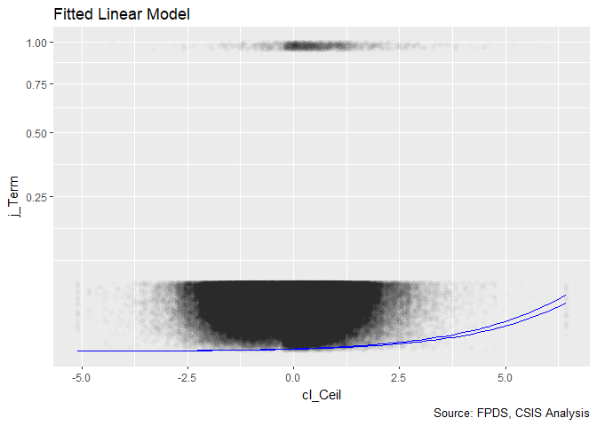

```r
#Plot the fitted model plot
Term_02A_curve<-function(x, Comp){invlogit(cbind(1,Comp,x) %*%  coef(Term_02A))}

#Competition curves
fitted_term_model(Term_smp,"cl_Ceil") + stat_function(fun = Term_02A_curve,
                             args=list(Comp=0),color="blue")+
  stat_function(fun = Term_02A_curve,
                             args=list(Comp=2),color="blue")
```

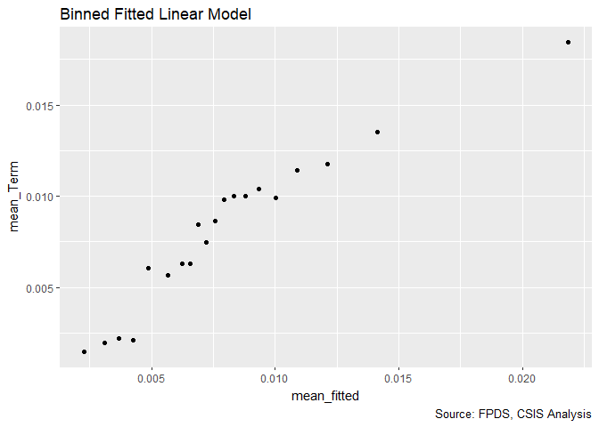

```r
#Plot the fitted values vs actual results
binned_fitted_versus_residuals(Term_02A)
```

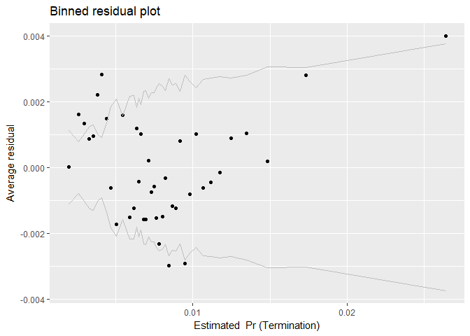

```r
#Plot residuals versus fitted
residuals_term_plot(Term_02A)+
  labs(x="Estimated  Pr (Termination)")
```

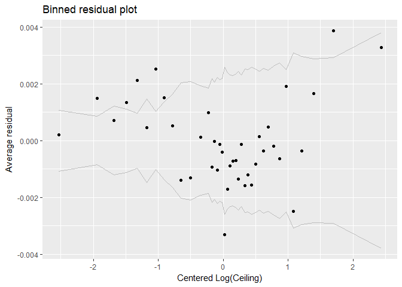

```r
residuals_term_plot(Term_02A,"cl_Ceil")+
  labs(x="Centered Log(Ceiling)")
```

### Model 02B: Cost Ceiling Squared

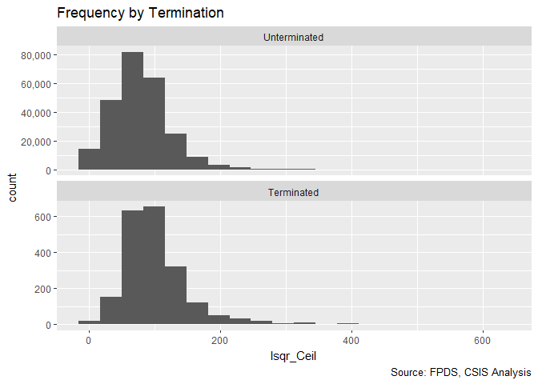

```r
Term_smp$clsqr_Ceil<-Term_smp$cl_Ceil^2
Term_smp$lsqr_Ceil<-Term_smp$l_Ceil^2


#Frequency Plot
freq_continuous_term_plot(Term_smp,"lsqr_Ceil")
```

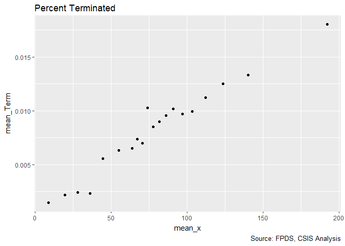

```r
#Percent Terminated Plot
binned_percent_term_plot(Term_smp,"lsqr_Ceil")
```

```r
#Model
Term_02B <- glm (data=Term_smp,
                 b_Term ~n_Comp + cl_Ceil + clsqr_Ceil, family=binomial(link="logit"))
display(Term_02B)
```

```
## glm(formula = b_Term ~ n_Comp + cl_Ceil + clsqr_Ceil, family = binomial(link = "logit"),
##     data = Term_smp)
##             coef.est coef.se
## (Intercept) -4.79     0.05
## n_Comp      -0.09     0.03
## cl_Ceil      0.58     0.03
## clsqr_Ceil  -0.04     0.01
## ---
##   n = 248258, k = 4
##   residual deviance = 22778.5, null deviance = 23346.1 (difference = 567.6)
```

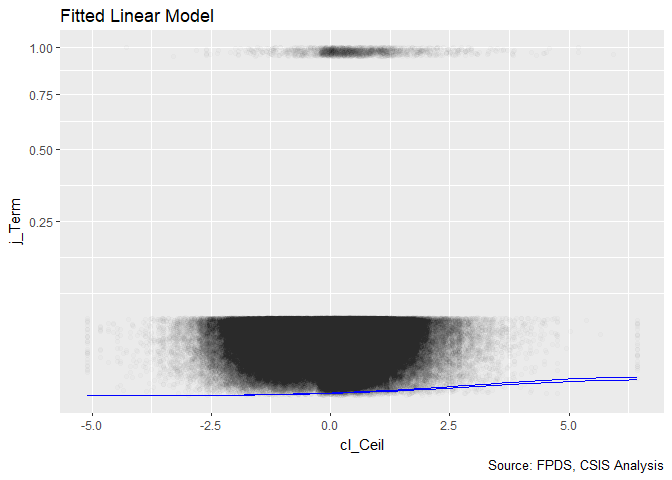

```r
#Plot the fitted model plot
Term_02B_curve<-function(x, Comp){invlogit(cbind(1,Comp,x, x^2) %*%  coef(Term_02B))}

#Competition curves
fitted_term_model(Term_smp,"cl_Ceil") + stat_function(fun = Term_02B_curve,
                             args=list(Comp=0),color="blue")+
  stat_function(fun = Term_02B_curve,
                             args=list(Comp=2),color="blue")
```

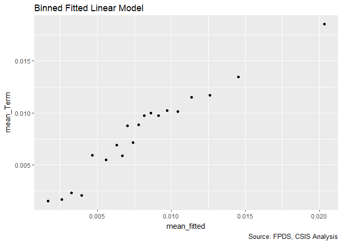

```r
#Plot the fitted values vs actual results
binned_fitted_versus_residuals(Term_02B)
```

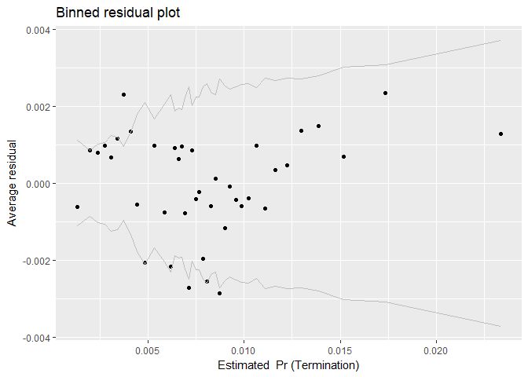

```r
#Plot residuals versus fitted
residuals_term_plot(Term_02B)+
  labs(x="Estimated  Pr (Termination)")
```

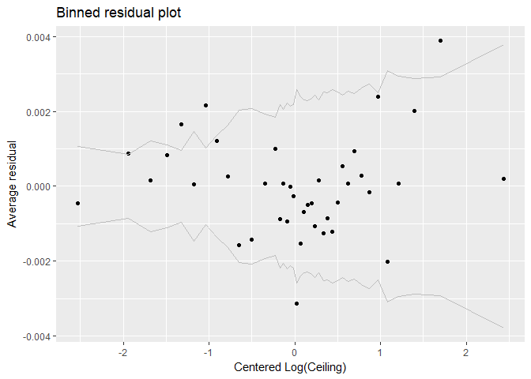

```r
residuals_term_plot(Term_02B,"cl_Ceil")+
  labs(x="Centered Log(Ceiling)")
```

Contracts with very small or very large ceilings appear have a negative coefficient for calculating termination. On the upper end, this might represent contracts that are “too large to fail”" or simply that above a certain size, risk stops rising. Adding the log(Ceiling) squared greatly reduces the apparent pattern in the residuals, although more than 5 percent of the binned residuals still fall outside the 95% confidence interval.